# Exercise #3

Fortgeschrittene Statistische Software für NF

Andreas Wallner (11803978)  
2025-06-04

## General Remarks

- You can submit your solutions in teams of up to 3 students.
- Include all your team-member’s names and student numbers (Matrikelnummern) in the `authors` field.
- Please use the exercise template document to work on and submit your results.
- Use a level 2 heading for each new exercise and answer each subtask next to its bullet points or use a new level 3 heading if you want.
- Always render the R code for your solutions (`echo=TRUE`) and make sure to include the resulting data in your rendered document.
  - Make sure to not print more than 10 rows of data (unless specifically instructed to).
- Always submit both the rendered document(s) as well as your source Rmarkdown or Quarto document. Submit the files separately on moodle, **not** as a zip archive.
- Submission format is HTML. Other formats will lead to a deduction of points.

## Exercise 1: Initializing git (4 Points)

For this whole exercise sheet we will be tracking all our changes to it in git.

1. Start by initializing a new R project with git support, called `2025-exeRcise-sheet-3`. If you forgot how to do this, you can follow this [guide](https://malikaihle.github.io/Introduction-RStudio-Git-GitHub/rstudio_project.html).
2. Commit the files generated by Rstudio.
3. For all of the following tasks in this exercise sheet we ask you to always commit your changes after finishing each subtask e.g. create a commit after task *1d*, *1e* etc.

> Note: This applies only to answers that have text or code as their answer. If you complete tasks in a different order or forget to commit one, this is no problem. If you change your answers you can just create multiple commits to track the changes.
4. Name 2 strengths and 2 weaknesses of git. (Don’t forget to create a commit after this answer, see *1c*)
   - Strengths:
     - Industry standard (nearly every company that deals with software development uses git
     - great for collaboration
   - Weaknesses:
     - git struggles with binary files(e.g. non-text-files such as pdf, images,…)
     - git struggles with large files
5. Knit this exercise sheet. Some new files will automatically be generated when knitting the sheet e.g. the HTML page. Ignore these files, as we only want to track the source files themselves. You can, but don’t need to create a `.gitignore` file. Just do not commit these files manually.

## Exercise 2: Putting your Repository on GitHub (3 Points)

For this task you will upload your solution to GitHub.

1. Create a new repository on GitHub in your account named `exeRcise-sheet-3`. Make sure you create a **public repository** so we are able to see it for grading. Add the link to the repository below:

[Link to the Github Repository](https://github.com/awa0890/exeRcise-sheet-3.git)

1. Push your code to this new repository by copying and executing the snippet on github listed under `…or push an existing repository from the command line`.
2. Regularly push your latest changes to GitHub again and especially do so when you are finished with this sheet.

## Exercise 3: Pixar Films (4 Points)

Download the `pixar_films` and `public_response` datasets from the GitHub repository and track them in git.

```r
link <- "https://raw.githubusercontent.com/rfordatascience/tidytuesday/main/data/2025/2025-03-11/"
pixar_films_link <- paste0(link, "pixar_films.csv")
public_response_link <- paste0(link, "public_response.csv")
pixar_films <- read.csv(pixar_films_link)
public_response <- read.csv(public_response_link)
system("git add pixar_films.csv public_response.csv")
```

```
[1] 0
```

Link: https://github.com/rfordatascience/tidytuesday/tree/main/data/2025/2025-03-11

For small datasets like these adding them to git is not a problem.

1. Load the `pixar_films` dataset into R. Clean the dataset by removing films without a title. Inspect the variable `film_rating`. What are the possible values and what do they mean? Create a factor variable for the film rating. Why is this appropriate?

```r
library(tidyverse)
pixar_films <- pixar_films %>% drop_na(film)
pixar_films <- pixar_films %>%
  mutate(film_rating = as.factor(pixar_films$film_rating))
```

The character variable `film_rating` is based on the Motion Picture Association film rating system and the possible values are:

In General the Motion Picture Association film rating system has the following values:

- G - General Audiences (All ages admitted)
- PG - Parental Guidance Suggested (*Some material may not be suitable for children*)
- PG-13 - Parents Strongly Cautioned (Some material may be inappropriate for children under 13)
- R - Restricted (Under 17 requires accompanying parent or adult guardian)
- NC-17 - Adults Only (No one 17 and under admitted)

**In this dataset there are just three values possible:**

- G - General Audiences (All ages admitted)
- PG - Parental Guidance Suggested (*Some material may not be suitable for children*)
- N/A - Not rated (yet?)

It is appropriate to use a factor for the variable film_rating, because it was a character variable before and a factor variable allows us to create correct and meaningful plots based on the factor variable and doing calculations based on the factor variable, which cannot be done on a character variable.

2. Inspect the film titles manually. Which films form a film series? A film series can be identified by a common word in the titles of the films, often in conjunction with a number in the title, e.g. “Despicable Me” and “Despicable Me 2”. Create a dataframe which displays a list of the different series with the titles of the films and how many films belong to the series. Output the dataframe.

```r
head(pixar_films$film,10)
```

```
 [1] "Toy Story"       "A Bug's Life"    "Toy Story 2"
 [4] "Monsters, Inc."  "Finding Nemo"    "The Incredibles"
 [7] "Cars"            "Ratatouille"     "WALL-E"
[10] "Up"
```

```r
film_series <- c("Toy Story", "Cars","Incredibles")
pixar_films <- pixar_films %>%
  mutate(series = str_extract(film, paste(film_series, collapse = "|")))
summary_film_series <- pixar_films %>%
  filter(!is.na(series)) %>%
  group_by(series) %>%
  summarise(
    films=paste(film, collapse = "; "),
    amount = n()
  )
summary_film_series
```

```
# A tibble: 3 × 3
  series      films                                            amount
  <chr>       <chr>                                             <int>
1 Cars        Cars; Cars 2; Cars 3                                  3
2 Incredibles The Incredibles; Incredibles 2                        2
3 Toy Story   Toy Story; Toy Story 2; Toy Story 3; Toy Story 4      4
```

3. Load the `public_response` dataframe into R. Convert the `cinema_score` variable into a factor while ensuring the factor levels are defined in ascending order, from the lowest to the highest score. Combine `public_response` with the `pixar_films` dataset using an appropriate merge variable.

```r
public_response$cinema_score <- factor(public_response$cinema_score,
                                       levels = (c("F",
                                                   "D-", "D", "D+",
                                                   "C-", "C", "C+",
                                                   "B-", "B", "B+",
                                                   "A-", "A", "A+")),
                                       ordered = TRUE)
merged_df <- full_join(public_response, pixar_films, by = "film")
head(merged_df,10)
```

```
              film rotten_tomatoes metacritic cinema_score
1        Toy Story             100         95            A
2     A Bug's Life              92         77            A
3      Toy Story 2             100         88           A+
4   Monsters, Inc.              96         79           A+
5     Finding Nemo              99         90           A+
6  The Incredibles              97         90           A+
7             Cars              74         73            A
8      Ratatouille              96         96            A
9           WALL-E              95         95            A
10              Up              98         88           A+
   critics_choice number release_date run_time film_rating
1              NA      1   1995-11-22       81           G
2              NA      2   1998-11-25       95           G
3             100      3   1999-11-24       92           G
```

[output cut: 18 more lines]

4. Choose one of the variables representing the public response and create a bar plot for the films belonging to a series. Here are the details of the plot:
   - The film series are represented on the x-axis.
   - Your chosen public response variable is displayed on the y-axis.
   - Each film in the series is represented as a separate bar. Bars are grouped by film under their respective series on the x-axis. Order the bars within a series according to the release date of the films.
   - A title and axis labels for context.

   What do you notice when comparing the scores of the films in a series? Do you see any patterns?

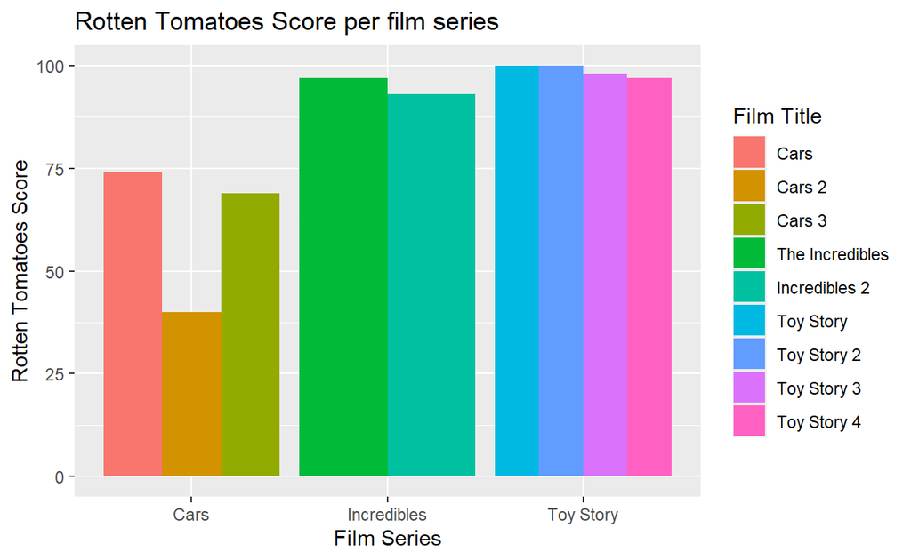

```r
bar_plot_data <- merged_df %>%
  filter(!is.na(series)) %>%
  arrange(series, release_date) %>%
  mutate(film=factor(film, levels = unique(film)))

plot <- ggplot(bar_plot_data,
               aes(x = series,
                   y = rotten_tomatoes,
                   fill = film)) +
  geom_bar(stat = "identity", position = position_dodge()) +
  labs(
    title = "Rotten Tomatoes Score per film series",
    x = "Film Series",
    y = "Rotten Tomatoes Score",
    fill = "Film Title"
  )
plot
```

## Exercise 4: Open Analysis (4 points)

This exercise is a bit more open-ended. You can choose any dataset from [Our World in Data](https://ourworldindata.org/) and analyze it, while determining the research question yourself.

1. Go to https://github.com/owid/owid-datasets/tree/master/datasets and choose a dataset that interests you. You can have a look at https://ourworldindata.org/ to gather some inspiration.
2. Download the dataset and track it in git.

```r
time_spend <- read.csv("C:/Users/Dell 7390/Desktop/Andreas Wallner/LMU/Neuer Ordner/Fortgeschrittene Statistische Software für NF/Exercise_3/2025-exeRcise-sheet-3/How Europeans spend their time - European Commission (2004).csv", header=TRUE)
```

3. Put the name / title of the dataset and a link to it below.
- Dataset Name: How Europeans spend their time - European Commission
- Link: https://github.com/owid/owid-datasets/tree/master/datasets/How%20Europeans%20spend%20their%20time%20-%20European%20Commission%20(2004)
4. Come up with a (research) question you want to answer with the data and briefly explain why you believe this is an interesting question within one sentence. It should be a question that can be answered with the dataset and using R.

   Question: Who has the most free time in Europe regarding sex and different countries?

   Importance: People who have more free time than others are potentially more interested in further activities like sports, fitness, reading, tv, gaming,… . That information can be a viable source for companies in these segments to concentrate on specific markets with people with more free time.
5. Use R to answer your chosen question. Please limit your analysis to the functions and techniques we have covered so far in the course. You are **not expected** to use advanced statistical models or external packages which haven’t been introduced.

```r
library(tidyverse)

filtered_time_spend <- time_spend %>%
  select(Entity,
         Free.time..women..European.Commission..2004..,
         Free.time..men..European.Commission..2004..) %>%
  mutate(free_time_women=Free.time..women..European.Commission..2004..,
         free_time_men=Free.time..men..European.Commission..2004..)
summary(filtered_time_spend)
```

```
    Entity          Free.time..women..European.Commission..2004..
 Length:10          Min.   :248.0
 Class :character   1st Qu.:276.5
 Mode  :character   Median :296.6
                    Mean   :297.4
                    3rd Qu.:319.2
                    Max.   :351.8
 Free.time..men..European.Commission..2004.. free_time_women
 Min.   :286.0                               Min.   :248.0
 1st Qu.:325.0                               1st Qu.:276.5
 Median :329.8                               Median :296.6
 Mean   :333.8                               Mean   :297.4
 3rd Qu.:348.1                               3rd Qu.:319.2
 Max.   :368.0                               Max.   :351.8
 free_time_men
 Min.   :286.0
 1st Qu.:325.0
 Median :329.8
 Mean   :333.8
 3rd Qu.:348.1
 Max.   :368.0
```

- Country with the most free time for women

```r
most_freetime_women <- filtered_time_spend %>%
  select(Entity, free_time_women) %>%
  arrange(desc(free_time_women)) %>%
  slice(1)
most_freetime_women
```

```
  Entity free_time_women
1 Norway        351.7557
```

- Country with the least free time for women

```r
least_free_time_women <- filtered_time_spend %>%
  select(Entity, free_time_women) %>%
  arrange(free_time_women) %>%
  slice(1)
least_free_time_women
```

```
  Entity free_time_women
1 France             248
```

- Country with the most free time for men

```r
most_freetime_men <- filtered_time_spend %>%
  select(Entity, free_time_men) %>%
  arrange(desc(free_time_men)) %>%
  slice(1)
most_freetime_men
```

```
   Entity free_time_men
1 Finland           368
```

- Country with the least free time for men

```r
least_free_time_men <- filtered_time_spend %>%
  select(Entity, free_time_men) %>%
  arrange(free_time_men) %>%
  slice(1)
least_free_time_men
```

```
  Entity free_time_men
1 France           286
```

Observations:

- Women have a free time of 297.4 minutes on average, while men have 333.8 min of free time on average a day.
- Mean and Median are close, so there are no outliers.
- Women in Norway have the most free time (351.76 min), while women in France have the least free time (248 min).
- Men in Finland have the most free time (368 min), while men in France have the least free time (286 min).
- Men have on average more free time then women.
- Men and Women in France have the least free time of all observed countries.

Conclusion:

- For companies who offer free time activities it could make sense to focus their marketing campaigns on Norway, Finland and Germany, because in these countries people have the most free time.
- Otherwise, marketing campaigns could be less effective in France, because the French have the least free time in the observed countries.
6. Create a meaningful plot / figure with the dataset. Make sure to provide a figure caption (via the chunk options / Rmarkdown) and correctly label the figure.

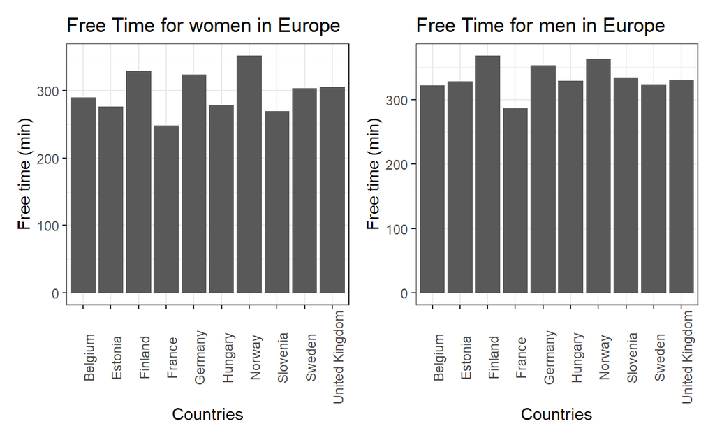

Figure 1: Free Time for women and men in selected european countries

```r
library(patchwork)
plot_free_time_women <- ggplot(data = filtered_time_spend,
                               aes(x=Entity,y=free_time_women)) +
  geom_bar(stat = "identity", position = position_dodge()) +
  theme_bw() +
  theme(axis.text.x = element_text(angle = 90)) +
  xlab("Countries") +
  ylab("Free time (min)") +
  ggtitle("Free Time for women in Europe")
plot_free_time_men <- ggplot(data = filtered_time_spend,
                             aes(x=Entity, y=free_time_men)) +
  geom_bar(stat = "identity", position = position_dodge()) +
  theme_bw() +
  theme(axis.text.x = element_text(angle = 90)) +
  xlab("Countries") +
  ylab("Free time (min)") +
  ggtitle("Free Time for men in Europe")
(plot_free_time_women | plot_free_time_men)
```

## Final Note

Make sure to push all your commits and changes to GitHub before submitting the exercise sheet.